# Is the hurdle component just a 0/1 model? Could a 4PL do that part?

Published

June 26, 2026

## The question

In the *D. suzukii* productivity model we use a **hurdle** family (`hurdle_gamma` / `hurdle_lognormal`) with two linear predictors:

```r
prod_form <- brms::bf(prod ~ logd * temp_c * sex,   # mu: clutch size | reproduced
                      hu   ~ logd * temp_c * sex)   # hu: P(zero offspring)
```

Daniel asked: *isn’t the hurdle component just a 0/1 (Bernoulli) model? Couldn’t we use the same 4PL for that part?*

**Yes to both.** The hurdle part is a binary model, and it is exactly the 4PL with the asymptotes pinned at 0 and 1.

## What the hurdle component is

In brms’s hurdle families the response is split into two pieces:

- **`hu`** — a **Bernoulli / logistic** model for the probability of a *zero* (here, producing no offspring). Default link is **logit**. So $\operatorname{logit} P(\text{zero}) = \text{linear in } (\log_{10}d,\ T,\ \text{sex},\ \text{interactions})$, and $P(\text{reproduce}) = 1 - P(\text{zero})$.
- **`mu`** — the positive part (Gamma or log-normal) for *how many* offspring, among flies that reproduced.

So the hurdle component **is** a 0-vs-nonzero model. Our productivity code reads the reproduction LT50 straight off this logit: $\log_{10}d_{50}(T) = -\,(I + T\,t)/(D + DT\,t)$ — the point where $P(\text{reproduce}) = 0.5$ — then takes its temperature slope for $z$ and its crossing of $\log_{10}60$ for $CT_{max,1h}$.

## Why that logistic *is* a 4PL with fixed asymptotes

Our survival 4PL (identity link, disjoint-bounds reparameterisation) is

$$p = \text{low} + \frac{\text{up}-\text{low}}{1+\exp\!\big(k(\log_{10}d - \text{mid})\big)} .$$

Set $\text{low}=0$ and $\text{up}=1$ and it collapses to the **two-parameter logistic**

$$p = \frac{1}{1+\exp\!\big(k(\log_{10}d - \text{mid})\big)}
= \operatorname{inv\_logit}\!\big(-k(\log_{10}d - \text{mid})\big),$$

which is exactly a logistic regression with slope $-k$ and intercept $k\cdot\text{mid}$ on the $\log_{10}d$ axis. The hurdle’s `hu` is this same curve (modelling the *zero* probability), with the slope and midpoint made linear in temperature via the `logd * temp_c` interaction.

So **reproduction incidence is a dose-response curve in log-time, just like survival** — and the same `tls()`/`extract_tdt()` machinery applies. The only thing the 4PL adds over the hurdle’s logit is **free asymptotes**.

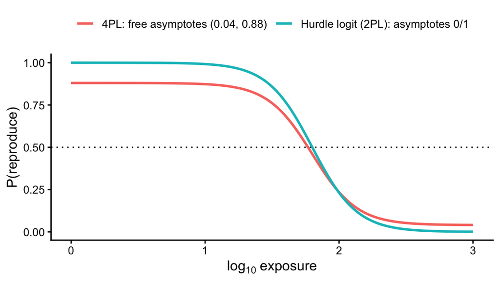

```r
suppressPackageStartupMessages(library(ggplot2))
logd <- seq(0, 3, length.out = 200)
k <- 6; mid <- 1.8
two_pl  <- plogis(-k * (logd - mid))                       # logit / 2PL: 1 -> 0
four_pl <- 0.04 + (0.88 - 0.04) / (1 + exp(k * (logd - mid)))  # free asymptotes
d <- rbind(
  data.frame(logd, p = two_pl,  model = "Hurdle logit (2PL): asymptotes 0/1"),
  data.frame(logd, p = four_pl, model = "4PL: free asymptotes (0.04, 0.88)")
)
ggplot(d, aes(logd, p, colour = model)) +
  geom_line(linewidth = 1) +
  geom_hline(yintercept = 0.5, linetype = 3) +
  labs(x = expression(log[10]~"exposure"), y = "P(reproduce)", colour = NULL) +
  theme_classic(base_size = 12) + theme(legend.position = "top")
```

## When to use which

|  | Hurdle logit (`hu`, current) | 4PL for incidence |
| --- | --- | --- |
| Asymptotes | fixed at 0 and 1 | free (`low`, `up`) |
| Both parts in one fit? | **yes** — zero-model + count-model together | no; fit incidence like survival, count part separately (or a custom non-linear hurdle `hu`) |
| z / CTmax | read off the logit 50% point | same `tls()`/`extract_tdt()` machinery |
| Best when | a (near-)0/1 incidence curve **and** you want clutch size from the same model | a real floor/ceiling exists (e.g. a fraction never reproduces regardless of exposure) |

For the fly data the incidence asymptotes are close to 0/1, so the logit and a 4PL give essentially the same incidence $z$/$CT_{max}$ — the simpler hurdle-logit is adequate **and** it returns clutch size in the same joint fit, which is the reason to use the hurdle family in the first place.

## Bottom line

- The hurdle component is a Bernoulli (0 vs >0) logistic model; it is the 4PL with `low = 0`, `up = 1`.
- A 4PL could model reproduction incidence directly (and would be preferable if the asymptotes are not 0/1), with the identical TDT extraction.
- We keep the hurdle’s logit because it bundles incidence and clutch size in one model and the asymptotes here are ~0/1, so nothing is lost.

## Reading it off the posterior (`prod_post`): `b_` vs `b_hu_`

A hurdle-Gamma fit is two models in one, so `posterior::as_draws_df()` returns two families of coefficients, told apart by the column-name prefix:

- **`b_hu_...`** — the **hurdle** part: the logistic model for $P(\text{zero offspring})$, i.e. *whether* a fly reproduces (the binary / incidence part, the simplified 4PL above). `prod_eff("b_hu_", ...)` reads these for the incidence $z$/$CT_{max}$.
- **`b_...`** — the **Gamma** (`mu`) part: clutch size among flies that *did* reproduce (the count / magnitude part). `prod_eff("b_", ...)` reads these for the duration-sensitivity $b(T)$.

brms fits both parts simultaneously; the main distributional parameter (`mu`) gets plain `b_` names and the hurdle parameter (`hu`) gets `b_hu_` names.

See also: [[project_beta_binomial_link_choice]], [[project_z_ctmax_derivation]].